# 14-1-1b checks

Emma Wood

13/06/2022

We use Beachwatch data from the Marine Conservation Society (MCS) to report 14-1-1b. Prior to the first time we used these data this we explored it thoroughly to ensure the trends were not being overly influenced by any variables.

It is not necessary to perform all checks every year, however we do need to check certain aspects of the data before using it:  
1. Number of volunteers impacts the estimate - Is the range of number of volunteers is very different to a ‘normal’ year? If so, data will need further scrutiny and a time series break and footnote may be needed.  
2. Are there any duplicate entries that need merging into a single entry?  
3. Have any litter types been dropped that should be included?  
4. Are all litter types in the main data are matched to a litter type in the sources data?  
6. Do trends look sensible given previous figures?

## 1. Number of volunteers

The range for number of volunteers each year can be seen in the box-plots below.  
The red line shows where number of volunteers = 10, and is just intended as a visual guide, however I think if the inter-quartile range falls above or below this line, we may not want to use the data for that year:

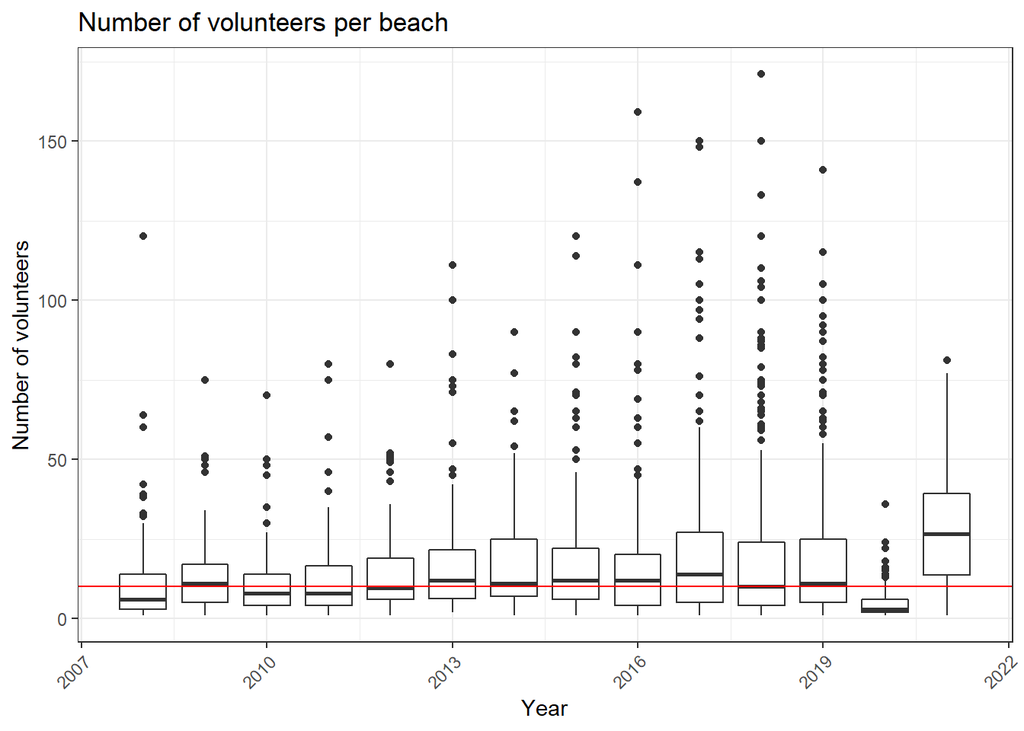

There is a clear positive correlation between the number of volunteers and the amount of plastic litter collected (see plot below).

In 2020 the number of volunteers was much lower than usual (significantly different to many of the earlier years based on non-overlapping boxes). Therefore, litter counts for 2020 are likely to be an under-estimate. In 2021 the number of volunteers was higher than usual (possibly significantly so based on the median not overlapping the boxes of earlier years) so counts for 2021 are likely to be an over-estimate compared to earlier years.

If the range does not look normal for the updated year please investigate and include a footnote in the data tables and on the platform. The observation status in the csv should also be changed (do all this in the 14_1_1b_update.R script).

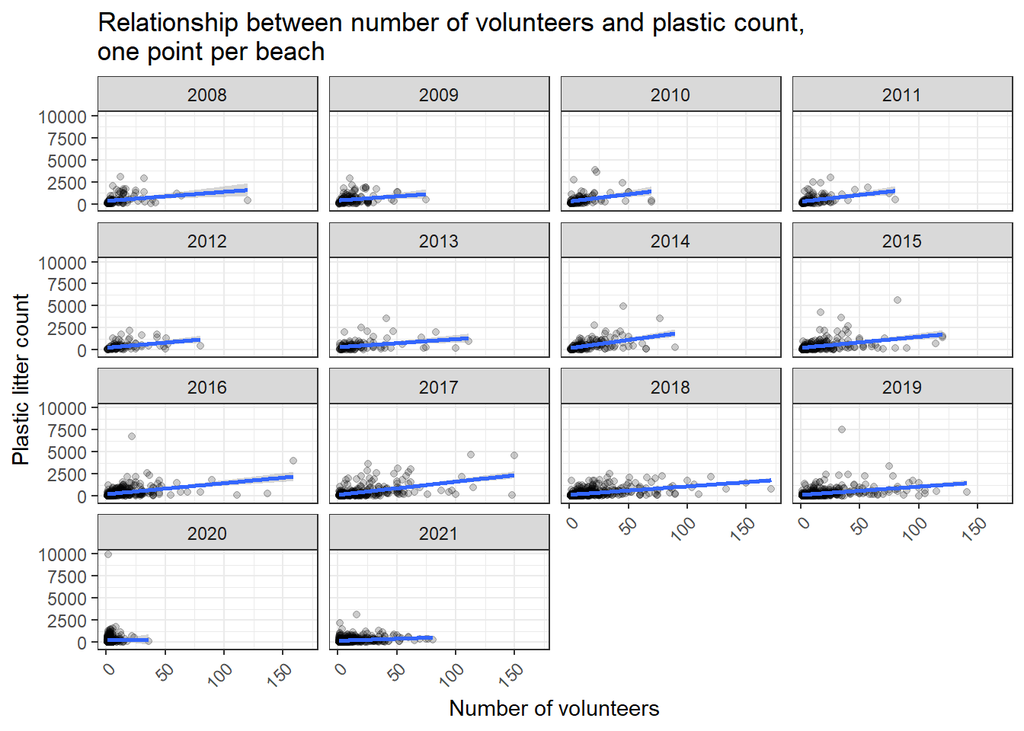

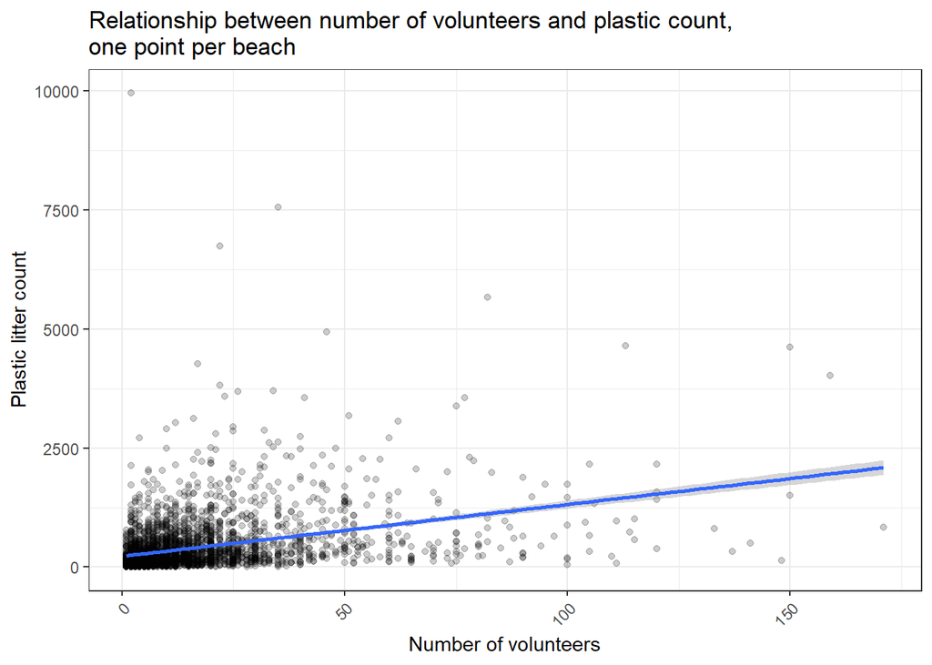

## 2. Duplicate entries

It is possible that two entries have been made for the same clean - this could for example occur if a volunteer sheet is missed by the organiser and therefore added as a separate entry.

| beach_id_new | date | time_survey_starts | n | year | survey_id | beach_id_old | beach_region | beach_country | total_volunteer_hours | total_volunteer_count | length_surveyed | average_width_of_surveyed_beach | plastic_polystyrene_4_6_pack_yokes | plastic_polystyrene_bag_ends_from_tear_off_plastic_bags | plastic_polystyrene_bagged_dog_faeces | plastic_polystyrene_bags_e_g_shopping | plastic_polystyrene_bags_mesh_e_g_vegetable | plastic_polystyrene_bags_small_e_g_freezer_vegetable | plastic_polystyrene_biofilm_support_media | plastic_polystyrene_bottles_containers_cleaner | plastic_polystyrene_bottles_containers_drinks | plastic_polystyrene_bottles_containers_drums_other | plastic_polystyrene_bottles_containers_toiletries_cosmetics | plastic_polystyrene_buckets | plastic_polystyrene_caps_lids | plastic_polystyrene_car_parts | plastic_polystyrene_cigarette_lighters_tobacco_pouches | plastic_polystyrene_cigarette_stubs | plastic_polystyrene_combs_hair_brushes_sunglasses | … |
| --- | --- | --- | --- | --- | --- | --- | --- | --- | --- | --- | --- | --- | --- | --- | --- | --- | --- | --- | --- | --- | --- | --- | --- | --- | --- | --- | --- | --- | --- | --- |
| 354 | 2017-09-18 | 10:05 | 2 | 2017 | 52112 | 2464 | south west england | england | 4 | 4 | 100 | 25 |  |  |  | 5 |  |  |  | 2 | 7 |  |  |  | 17 |  | 4 |  |  | … |
| 354 | 2017-09-18 | 10:05 | 2 | 2017 | 52956 | 2464 | south west england | england | 4 | 4 | 100 | 25 |  |  |  | 5 |  |  |  | 2 | 7 |  |  |  | 17 |  | 4 |  |  | … |
| 390 | 2019-09-21 | 11:00 | 2 | 2019 | 65886 | 2501 | wales | wales | 36 | 29 | 100 | 75 |  | 4 | 0 | 3 | 3 | 13 |  | 2 | 2 | 3 | 2 | 2 | 9 | 0 | 1 | 195 | 0 | … |
| 390 | 2019-09-21 | 11:00 | 2 | 2019 | 65923 | 2501 | wales | wales | 39 | 31 | 100 | 75 | 0 | 16 | 0 | 12 | 1 | 15 |  | 1 | 5 | 1 | 8 | 1 | 28 | 0 | 1 | 283 | 0 | … |
| 486 | 2017-09-17 | 10:00 | 2 | 2017 | 52625 | 2612 | north east england | england | 70 | 35 | 100 | 50 |  |  |  |  |  | 1 |  |  | 2 |  |  |  |  |  |  | 17 |  | … |
| 486 | 2017-09-17 | 10:00 | 2 | 2017 | 53140 | 2612 | north east england | england | 70 | 35 | 100 | 50 |  |  | 5 |  |  | 1 |  |  | 2 |  |  |  | 80 |  |  | 43 |  | … |

## 3. Litter types not included

The full MCS data includes litter categories, such as wood and ceramic, which are not pertinent to the indicator (which is only about plastic).

Columns (litter types) are selected based on some key words that are set in the 14.1.1b config file. The keywords used in this run were plastic_polystyrene, rubber, sanitary, medical.

Typos and column name changes in the data may lead to errors in future runs. Please check that the list of dropped columns in the table below does not include any items that should be included in the estimate of plastic litter. If there are, please edit the plastic_keywords in the config file so they are included.

It is also possible that some non-plastic litter items will be included in the estimate. The table showing litter type by source in the next section lists all items used in the estimate. Please check through them - if any items are included that should not be you may be able to edit the plastic_keywords to remove them, or you may need to edit 14-1-1b_update.R.

Please check all pages of the table below:

```
## [1] "Columns dropped from the data: "
```

```
##                                                                              not.included
## 1                                                                                  remove
## 2                                                                  other_pollutants_total
## 3                                                                   other_pollutants_desc
## 4                                                pollutants_paraffin_or_wax_pieces_1_10cm
## 5                                                  pollutants_paraffin_or_wax_pieces_10cm
## 6                                                 pollutants_paraffin_or_wax_pieces_0_1cm
## 7                                                       other_pottery_ceramic_items_total
## 8                                                        other_pottery_ceramic_items_desc
## 9                                                           pottery_ceramics_octopus_pots
## 10                                       pottery_ceramics_construction_material_e_g_tiles
## 11                                                                other_glass_items_total
## 12                                                                 other_glass_items_desc
## 13                                                                glass_light_bulbs_tubes
## 14                                                      glass_jars_incl_fragments_of_jars
```

[output cut: 74 more lines]

## 4. Matching of litter types to sources

There is a step in the code where litter types in the main data set are matched to a spreadsheet with the suspected source of each litter type. If there are discrepancies between the litter type names in the two datasets they will not join correctly.

There are 0 unmatched litter types. If there are any they will be listed below.

The following table shows the litter types retained in the dataset classified by suspected source (please check that there is nothing weird in here, and that all items are plastic related):

```
## [1] "Litter types included in estimate and classified by suspected source: "
```

```
## # A tibble: 75 x 2
##    litter_type                                             source
##    <chr>                                                   <chr>
##  1 plastic_polystyrene_4_6_pack_yokes                      public
##  2 plastic_polystyrene_bag_ends_from_tear_off_plastic_bags non-sourced
##  3 plastic_polystyrene_bagged_dog_faeces                   public
##  4 plastic_polystyrene_bags_e_g_shopping                   public
##  5 plastic_polystyrene_bags_mesh_e_g_vegetable             shipping
##  6 plastic_polystyrene_bags_small_e_g_freezer_vegetable    public
##  7 plastic_polystyrene_biofilm_support_media               non-sourced
##  8 plastic_polystyrene_bottles_containers_cleaner          shipping
##  9 plastic_polystyrene_bottles_containers_drinks           public
## 10 plastic_polystyrene_bottles_containers_drums_other      non-sourced
## # ... with 65 more rows
```

## 5. Trends

The plots below show the data plotted by year and country. Please check that they look reasonable, and investigate anything that looks strange.

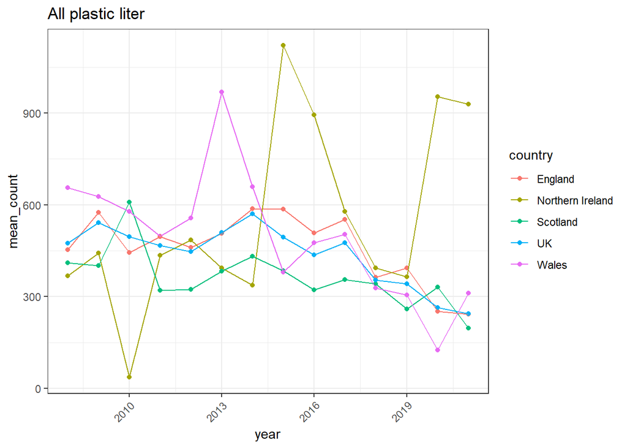

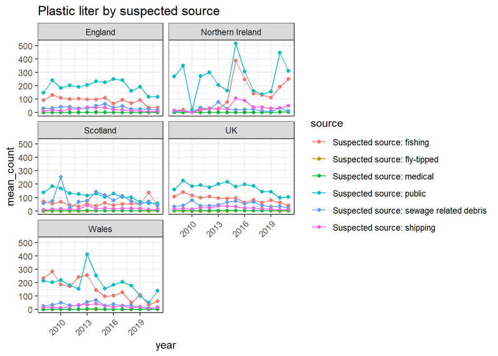